# Predicting a Diamond’s Cut

Isaiah De La Rosby

2023-03-12

# Introduction

This project will intend to predict the cut of a diamond given different variables related to the diamonds size, color, dimensions and more. We get this dataset from within the `ggplot2` library called diamonds. The original source of this dataset was actually somwaht hard to find and actually not fully verifiable. The best source I found was from a business textbook stating its from a Tiffany & CO snapshot price list from 2017. Working on this data set was quite easy and not much of a challenge to manipulate. It will be important to create accurate machine leanring models given we have such a nice data set. Let’s see how well we can do.

## Describing Variables

Although we didn’t have any missing data will still had to do some cleaning. After cleaning up our data set and removing the duplicate values we can look at what exactly each variable is and is measured in.

- `carat` : The weight of the diamond (200 milligrams per one carat)
- `price` : Price of the diamond (USD)
- `cut` : Quality of the diamonds cut (Fair, Good, Very Good, Premium, Ideal)
- `clarity` : Measure of how clear the diamond is (I1 (worst), SI2, SI1, VS2, VS1, VVS2, VVS1, IF (best))
- `x` : Length of diamond (mm)
- `y` : Width of diamond (mm)
- `z` : Depth of diamond (mm)
- `depth` : Total depth percentage = z / mean(x, y) = 2 * (x + y)
- `table` : Width of top of diamond relative to widest point

# Exploratory analysis

### Inspecting the Diamond

Before we start diving deep into the prediction side of this project it is important to see if there is anything we should keep in mind or change based on what we find in our analysis. We’ll start by looking at our outcome variable in this case `cut` and see if anything stands out.

We can see a couple things form these charts. The first being that there are not that many diamonds with a fair or good cut compared to the others. It’ll be important to get these right later since there could be some key things that tell us a diamond is worse.

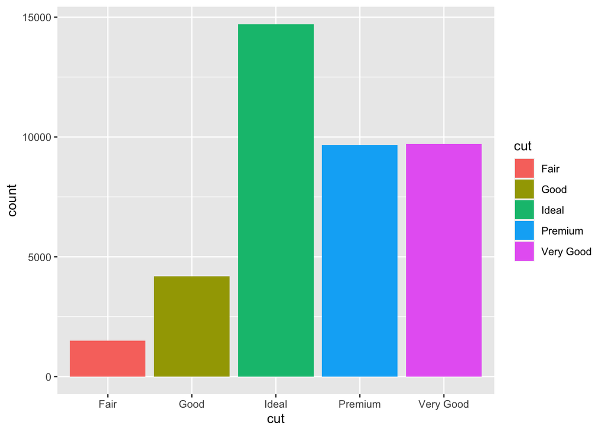

Given that lets look if carat might tell us anything about our cut. From the chart below it really doesn’t seem like there is anything special about the distribution of carat between the cuts. We can also see this holds for price and we will find out why in the next section.

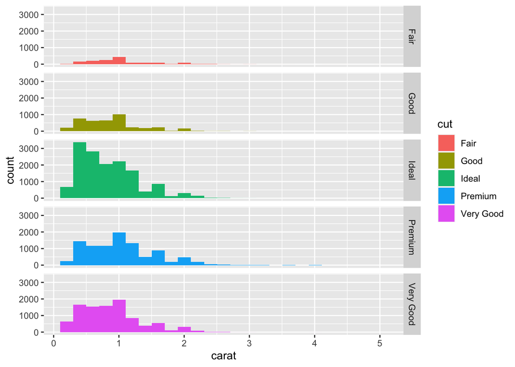

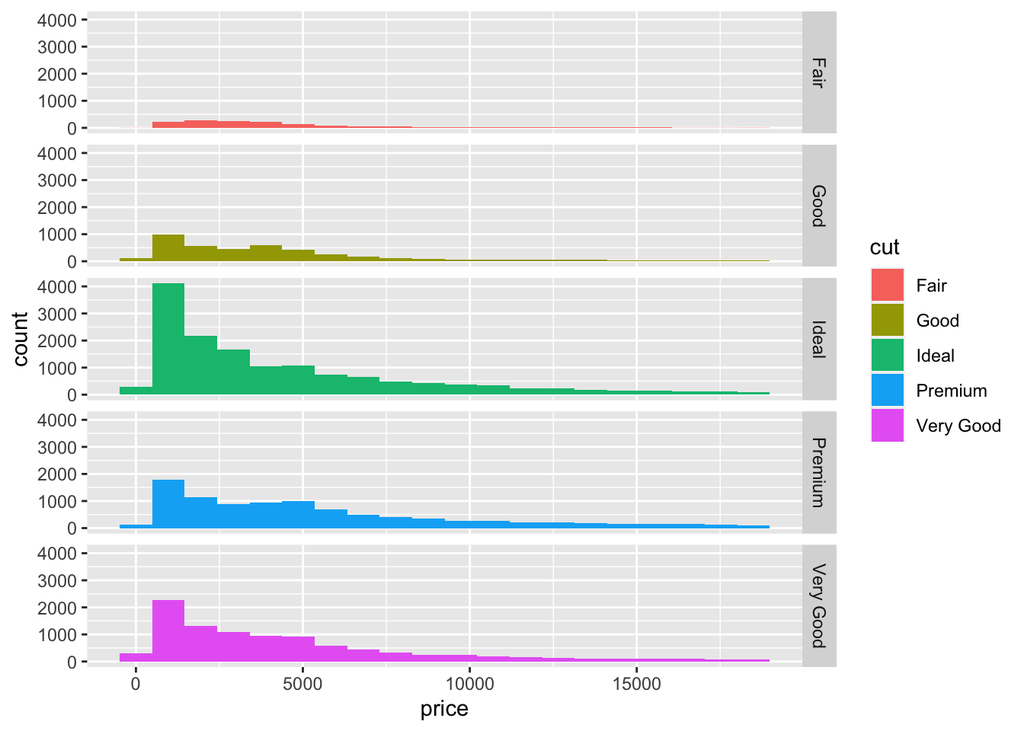

This chart shows us the exact same pattern among all cuts for price and carat. Possibly meaning the difference in cuts is negligible when trying to find the price.

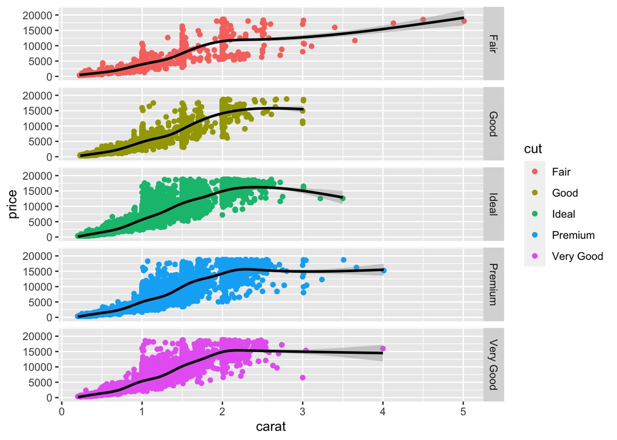

# Correlations

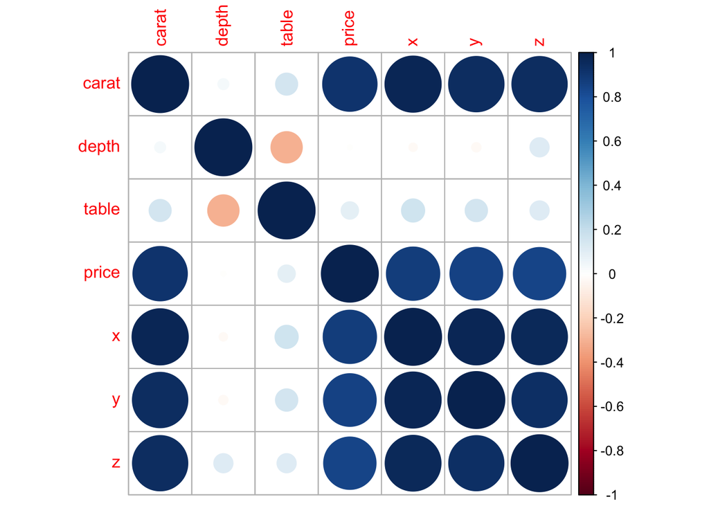

Well I wish I could say this looks like a diamond but honestly it looks more like a diamond sword from minecraft. We have a large square of correlations in the bottom right. This square is all realted to the dimensions of a diamond. Obviously the larger the x of a diamond we can expect a larger y and z value. Another important thing we see is that price is correlated with all size aspects of the diamond. It may seem like we should remove some of these at first and that may have been useful. Instead I decided to keep them around since some specific dimensions would be important given we have even more measurements for the size and shape of the diamond.

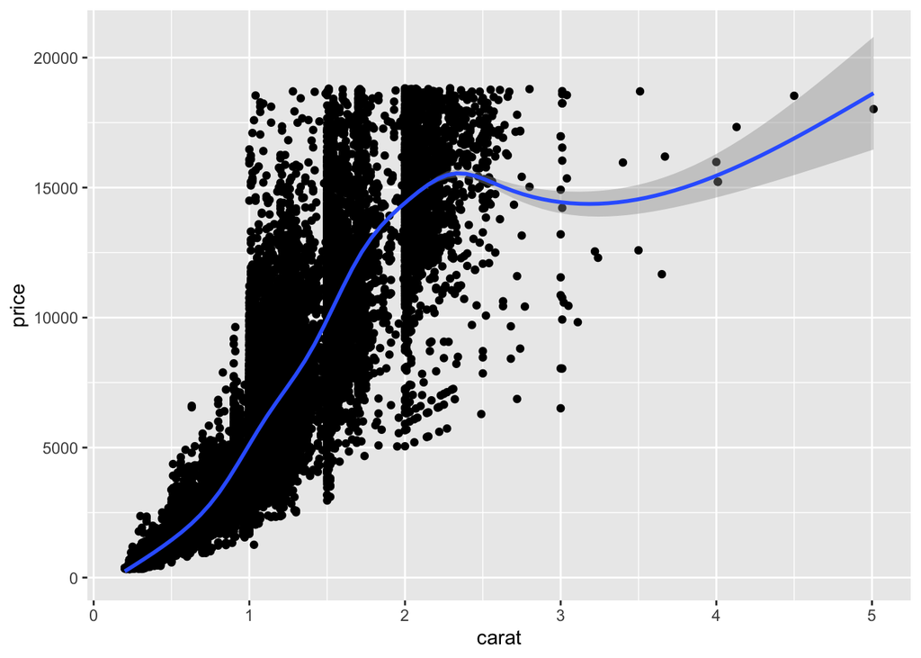

After seeing large chunks of diamonds on a carat line I decided to investigate further by doing some research. It turns out most of these spplits are standard carats for diamonds. This led me to chunk them out by these sections. It was also helpful for the visualization to get rid of diamonds with carat greater than 3.25.

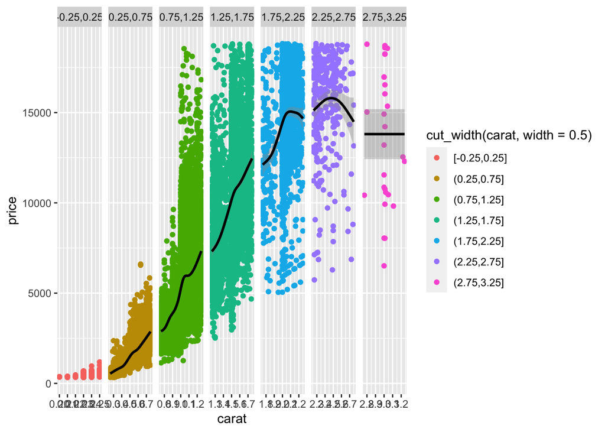

```r
dCleanLessCarat <- diamondsClean[diamondsClean$carat <= 3.25, ]

ggplot(dCleanLessCarat, aes(x=carat, y=price,color = cut_width(carat, width = .5))) +
  geom_point() +
  facet_wrap(~ cut_width(carat, width = .5), nrow = 1,scales = 'free_x') +
  geom_smooth(color='black')
```

This visualization is just another way of showing the clear patter between the sections of carats.

### Cleaning and Splitting our Diamonds

First we have to retrieve all that work we did on splitting and preparing our data loading it in. We also verify that the splits are correct.

```r
load('diamond_sets.rda')
```

```r
dim(diamonds_train)
```

```
## [1] 27827    10
```

```r
dim(diamonds_test)
```

```
## [1] 11929    10
```

This is our folding so that we can help our training be as accurate as possible. With this many points it may be hard to do a lot of folds so we decided on 5.

```r
diamonds_folds <- vfold_cv(diamonds_train,v = 5, strata = cut)
```

### Cooking our Diamond

Here we make our recipe involving all of our variables. We also normalize are numerical variables and make dummies of our categorical predictors.

```r
diamonds_recipe <- recipe(data = diamonds_train,
                          cut ~ price + carat + color + clarity + x + y + z) %>%
  step_dummy(all_nominal_predictors()) %>%
  step_normalize(all_predictors())
```

```r
save(diamonds_train,diamonds_test,diamonds_folds,diamonds_recipe,file = 'diamond_model_stuff.rda')
```

After saving our splits and recipe we can load it back in to decrease the knitting time of our html file. Now we are ready to test out some different models.

```r
load('diamond_model_stuff.rda')
```

Now that we wrapped up our diamond recipe nice and tightly we take it on to greater things. Until next time…  
…aaand we’re back! Wow it sure took a long time to shine, cut, and clean those dia…models. Now that we have our models ready lets load them in and see what our results were.

```r
load('pruned_dec_tree.rda')
load('random_forest_tune_isaac.rda')
load('tune_bt_cut.rda')
load('knn_details.rda')
```

# Model Analysis

### Taking our Diamond to an appraiser

We are going to use to metric of area under the ROC curve. Let’s take a look at all of the models and there respective `roc_auc` for our training data.

| model | mean | std_err |
| --- | --- | --- |
| Pruned Decision Tree | 0.7567321 | 0.0030625 |
| K Nearest Neighbors | 0.7300274 | 0.0029725 |
| Boosted Tree | 0.8636166 | 0.0009294 |
| Random Forest | 0.8703369 | 0.0002210 |

From this we actually have a quite close comparison but Random Forest takes the cake (or diamond), for the best `roc_auc`. It also has a lower standard error compared to boosted tree model. We will go ahead and use boosted tree and random forest models on our testing data since they were so close.

# Putting it to the Test

### To the Jeweler we go

Now that we chose our best model lets fit it to our testing data and see if we can be just as good at predicting the cut of our diamond with brand new data. Let’s load in our results and see what we came up with.

```r
load('random_forest_results.rda')
load('boosted_tree_results.rda')
```

Starting with the ROC we have

```r
roc_auc(final_rf_model_test,truth = cut, .pred_Fair:.pred_Ideal)
```

```
## # A tibble: 1 × 3
##   .metric .estimator .estimate
##   <chr>   <chr>          <dbl>
## 1 roc_auc hand_till      0.878
```

```r
roc_auc(final_bt_model_test,truth = cut, .pred_Fair:.pred_Ideal)
```

```
## # A tibble: 1 × 3
##   .metric .estimator .estimate
##   <chr>   <chr>          <dbl>
## 1 roc_auc hand_till      0.873
```

Pretty good lets take a closer look at the roc curve for each of the cuts for the random forest model since it did better. We are going to be looking for anything interesting given we are pretty good at predicting overall.

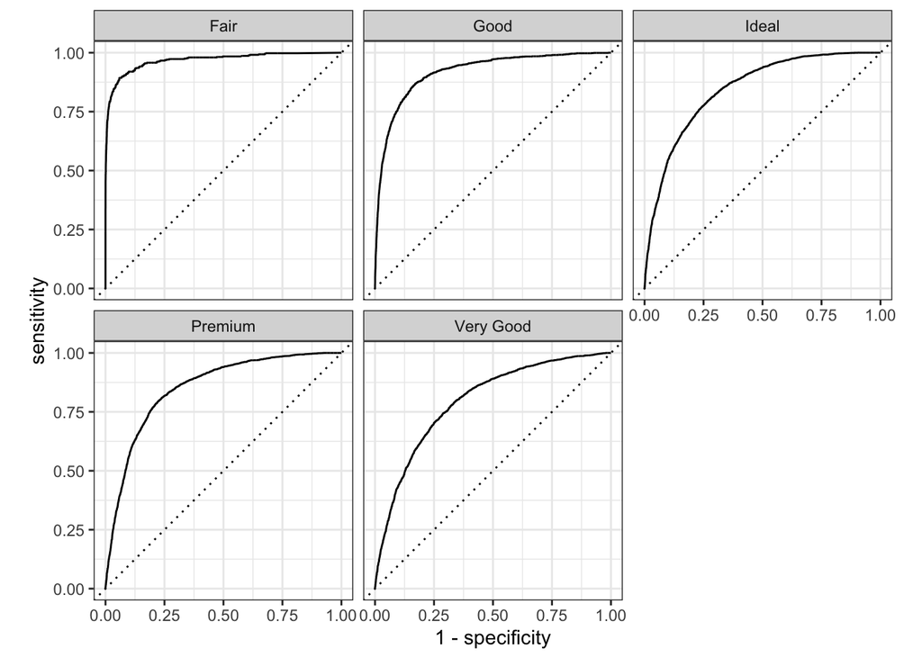

```r
roc_curve(final_rf_model_test,truth = cut, .pred_Fair:.pred_Ideal) %>%
  autoplot()
```

Wow. We have some surprises here. The first thing to notice is how accurately we predict the fair and good cut diamonds. If you recall we were interested in seeing if our model would be able to predict these correctly due to the relatively low amount of diamonds of those cuts we had.

## Variable Importance

Given we happen to be pretty good at predicting lets see what is helping us predict our cut so well.

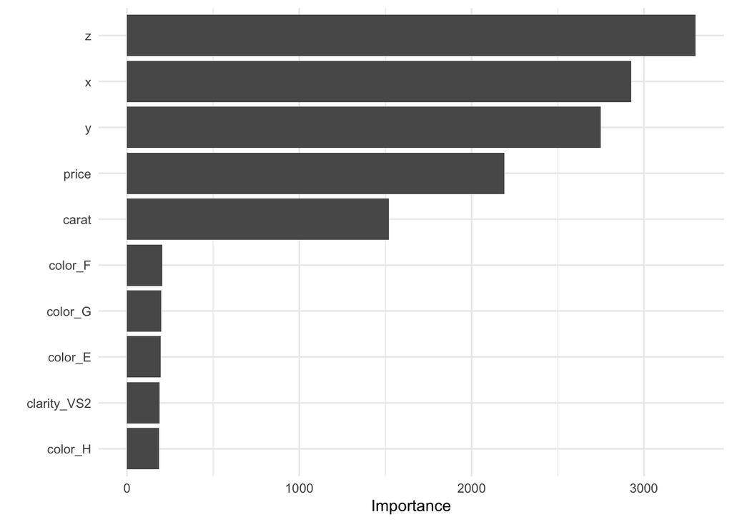

```r
final_rf_model %>% extract_fit_parsnip() %>%
  vip() +
  theme_minimal()
```

Well well well. It seems as though the dimensions of our diamond are the most important variables in predicting cut. In the beginning of this report we almost decided to remove these variables in some way due to the high correlation but maybe it worked out.

# Conclusion

### Selling our Diamonds

We have been on quite a journey through this project. We explored some interesting facts about diamonds and certain trends in the diamond industry when it comes to pricing. We also saw that diamonds are probably priced in a very specific way based on carat and price with slight influence from other things like color, clarity, and even cut. This although, would definitely be another interesting project to explore instead of diving deeper here.

While we were looking at patterns within our data set we decided to look at correlations to help with choosing variables for our model. Something very obvious discovered was the high correlation of the diamonds dimensions but not the specific measurements like depth and table. This may have led us, in another dimension, to remove these variables in some way. But it turned out that our thinking that specific dimensions might be very important for a certain cut of a diamond was correct!

It wasn’t a big surprise that random forest and boosted tree models were the best as we could more easily tune the hyper parameters and generally they seem to be more powerful models. It was great to see that we were able to accurately predict the cut of diamonds that even had less samples in our testing and training set. Overall, this project gave useful insight into the diamond world and provided me with an avenue to explore machine learning in a productive and inquisitive way.